# Project 2: Data Mining, Classification, Prediction

SDS322E

# Mining, Classification, Prediction

## Alice Liu

### Introduction

```r
library(tidyverse)
possum <- read_csv("~/project2/possum.csv")

possum <- possum %>% select(2:15)  # getting rid of X1 column
possum <- na.omit(possum)
head(possum)
```

```
## # A tibble: 6 x 14
##    case  site Pop   sex     age hdlngth skullw totlngth taill footlgth earconch
##   <dbl> <dbl> <chr> <chr> <dbl>   <dbl>  <dbl>    <dbl> <dbl>    <dbl>    <dbl>
## 1     1     1 Vic   m         8    94.1   60.4     89    36       74.5     54.5
## 2     2     1 Vic   f         6    92.5   57.6     91.5  36.5     72.5     51.2
## 3     3     1 Vic   f         6    94     60       95.5  39       75.4     51.9
## 4     4     1 Vic   f         6    93.2   57.1     92    38       76.1     52.2
## 5     5     1 Vic   f         2    91.5   56.3     85.5  36       71       53.2
## 6     6     1 Vic   f         1    93.1   54.8     90.5  35.5     73.2     53.6
## # … with 3 more variables: eye <dbl>, chest <dbl>, belly <dbl>
```

```r
possum %>% group_by(sex) %>% summarize(n = n())
```

```
## # A tibble: 2 x 2
##   sex       n
##   <chr> <int>
## 1 f        42
## 2 m        59
```

My Project 2 is over the possum dataset. This dataset measures various possum body lengths, and it also notes sex, age, and which location they were found in, and the different sites where the possums were trapped. I found the dataset in the github link provided on the instructions page. There are 101 total observations. In total, there are 14 variables. (1)case: observation number (2)site: one of seven locations the possums were trapped (3)Pop: classifies the sites as Victoria (Vic), or New South Wales or Queensland (other) (4)sex: male (m) or female (f) (5)age: age in years (6)hdlngth: head length in mm (7)skullw: skull width in mm (8)totlngth: total length in cm (9)taill: tail length in cm (10)footlgth: foot length in mm (11)earconch: ear conch length in mm (12)eye: distance from medial canthus to lateral canthus of right eye in mm (13)chest: chest girth in cm (14)belly: belly girth in cm. My binary variable that I will be measuring is sex (male or female). I have 42 female possums and 59 male possums.

### Cluster Analysis

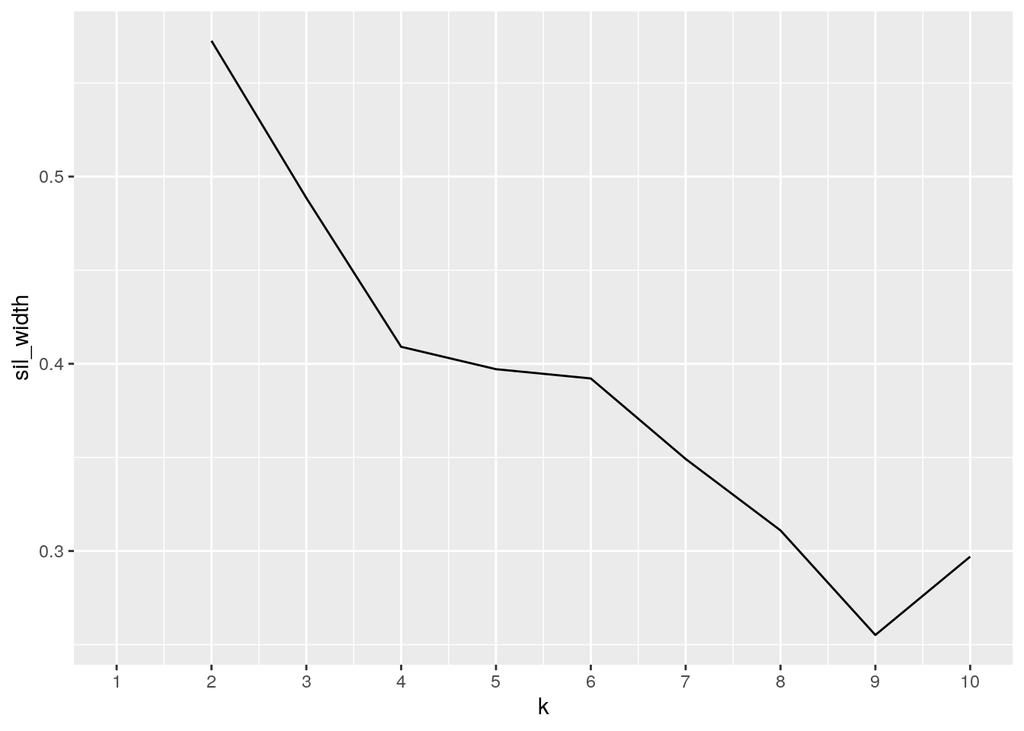

```r
# Finding optimal number of clusters k
library(cluster)
sil_width <- vector()
possum_num <- possum %>% select_if(is.numeric)
for (i in 2:10) {
    kms <- kmeans(possum_num, centers = i)
    sil <- silhouette(kms$cluster, dist(possum_num))
    sil_width[i] <- mean(sil[, 3])
}
ggplot() + geom_line(aes(x = 1:10, y = sil_width)) + scale_x_continuous(name = "k",
    breaks = 1:10)
```

```r
# Two is the optimal number of clusters


# Pam Clustering (Numeric Only)
pam1 <- possum %>% select_if(is.numeric) %>% scale %>% pam(k = 2)
pam1
```

```
## Medoids:
##      ID       case      site        age     hdlngth     skullw  totlngth
## [1,] 23 -0.9734572 -1.129442 0.09305531 -0.06556176 -0.2773075 0.4123838
## [2,] 92  1.3814931  1.405528 0.09305531 -0.32133702 -0.1161564 0.2932454
##           taill   footlgth   earconch        eye       chest      belly
## [1,] -0.5322895  0.9973895  1.2723865  0.3301443  0.46302442  0.8656916
## [2,]  0.2284828 -0.8832034 -0.6732578 -0.1421585 -0.03184824 -0.6007210
## Clustering vector:
##   [1] 1 1 1 1 1 1 1 1 1 1 1 1 1 1 1 1 1 1 1 1 1 1 1 1 1 1 1 1 1 1 1 1 1 1 1 1 1
##  [38] 1 1 1 1 1 1 2 1 1 1 1 2 2 1 1 2 2 2 1 2 2 2 2 2 2 2 2 2 2 2 2 2 2 2 2 2 2
##  [75] 2 2 2 2 2 2 2 2 2 2 2 2 2 2 2 2 2 2 2 2 2 2 2 2 2 2 2
## Objective function:
##    build     swap
## 3.233174 2.919679
##
## Available components:
##  [1] "medoids"    "id.med"     "clustering" "objective"  "isolation"
##  [6] "clusinfo"   "silinfo"    "diss"       "call"       "data"
```

```r
possum_num %>% slice(pam1$id.med)
```

```
## # A tibble: 2 x 12
##    case  site   age hdlngth skullw totlngth taill footlgth earconch   eye chest
##   <dbl> <dbl> <dbl>   <dbl>  <dbl>    <dbl> <dbl>    <dbl>    <dbl> <dbl> <dbl>
## 1    23     1     4    92.5   56.1     89    36       72.8     53.3  15.4    28
## 2    95     7     4    91.6   56.6     88.5  37.5     64.5     45.4  14.9    27
## # … with 1 more variable: belly <dbl>
```

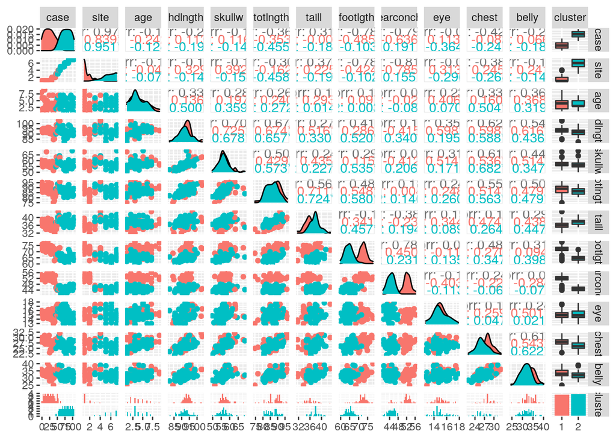

```r
# Visualization
library(GGally)
possum_num %>% mutate(cluster = as.factor(pam1$clustering)) %>%
    ggpairs(cols = 1:12, aes(color = cluster))
```

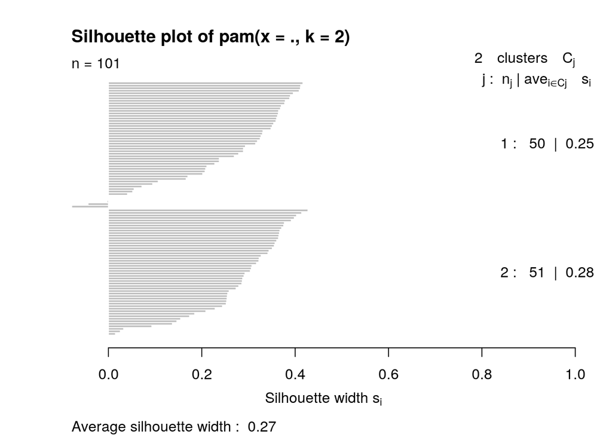

```r
# Goodness-of-Fit
plot(pam1, which = 2)
```

```r
pam1$silinfo$avg.width
```

```
## [1] 0.2655418
```

The silhouette plot shows that the silhouette coefficient is highest (optimal) when k = 2. However, the average silhouette width is 0.266, which means that the structure is weak and could be artificial. This makes sense as the 2 medioid variable values are overall pretty similar. Visualizing the cluster, ‘site’ shows the greatest difference between the two clusters. Age is the most similar between the two clusters. In terms of site, the first 3 sites have higher earconch and foot length, but lower head length. This could mean that the possums at the different sites develop differently due to their environment/diet.

### Dimensionality Reduction with PCA

```r
# PCA on my numeric variables
possum_pca <- possum %>% select(-case)
possum_pca_num <- possum_pca %>% select_if(is.numeric) %>% scale
rownames(possum_pca_num) <- possum$case
possum_pca <- princomp(possum_pca_num)
names(possum_pca)
```

```
## [1] "sdev"     "loadings" "center"   "scale"    "n.obs"    "scores"   "call"
```

```r
summary(possum_pca, loadings = T)
```

```
## Importance of components:
##                          Comp.1    Comp.2     Comp.3     Comp.4     Comp.5
## Standard deviation     2.068222 1.5877240 0.98651639 0.90036022 0.86397549
## Proportion of Variance 0.392756 0.2314615 0.08935879 0.07443227 0.06853802
## Cumulative Proportion  0.392756 0.6242174 0.71357623 0.78800851 0.85654652
##                            Comp.6     Comp.7     Comp.8     Comp.9   Comp.10
## Standard deviation     0.73760511 0.56643763 0.51521189 0.44060572 0.3725739
## Proportion of Variance 0.04995472 0.02946001 0.02437252 0.01782498 0.0127454
## Cumulative Proportion  0.90650124 0.93596125 0.96033377 0.97815875 0.9909042
##                            Comp.11
## Standard deviation     0.314743871
## Proportion of Variance 0.009095849
## Cumulative Proportion  1.000000000
##
## Loadings:
##          Comp.1 Comp.2 Comp.3 Comp.4 Comp.5 Comp.6 Comp.7 Comp.8 Comp.9 Comp.10
## site      0.260  0.474         0.136  0.144  0.101  0.224         0.445
## age      -0.219  0.109 -0.547  0.501 -0.504  0.360
## hdlngth  -0.394  0.157                0.255  0.208  0.558 -0.491  0.209 -0.102
## skullw   -0.343  0.191                0.530  0.354         0.591 -0.275
## totlngth -0.383  0.134  0.364 -0.165 -0.277  0.152        -0.285 -0.502
## taill    -0.124  0.447  0.472        -0.420        -0.150  0.284  0.284 -0.180
## footlgth -0.338 -0.369  0.166 -0.124                       0.218  0.376  0.704
## earconch -0.202 -0.524               -0.138         0.154  0.218  0.252 -0.664
## eye      -0.162  0.227 -0.550 -0.707 -0.134 -0.202 -0.154         0.146
##          Comp.11
## site      0.632
## age
## hdlngth  -0.308
## skullw
## totlngth  0.489
## taill    -0.398
## footlgth
## earconch  0.277
## eye       0.122
##  [ reached getOption("max.print") -- omitted 2 rows ]
```

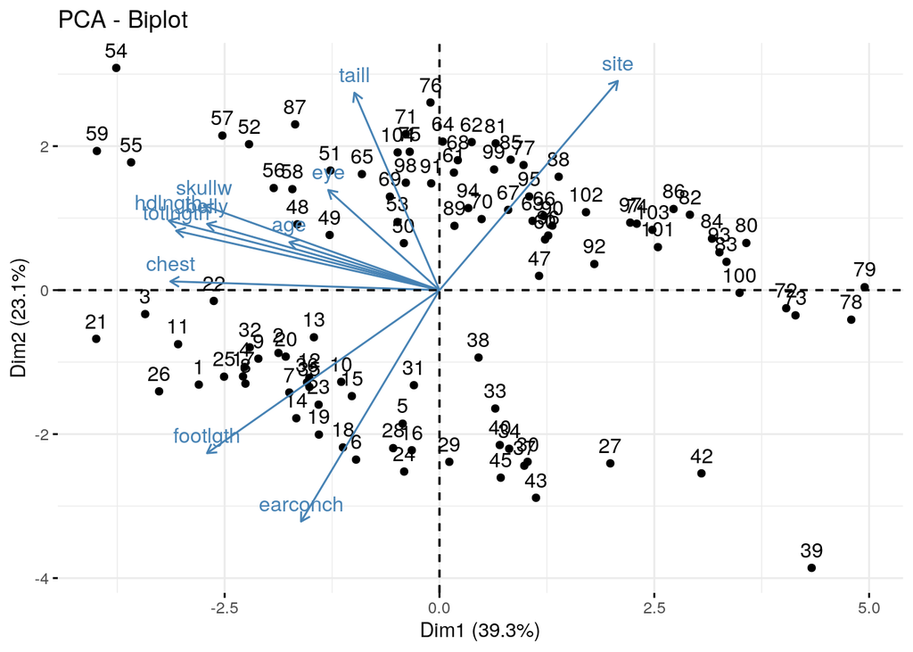

```r
# Visualization
library(factoextra)
fviz_pca_biplot(possum_pca)
```

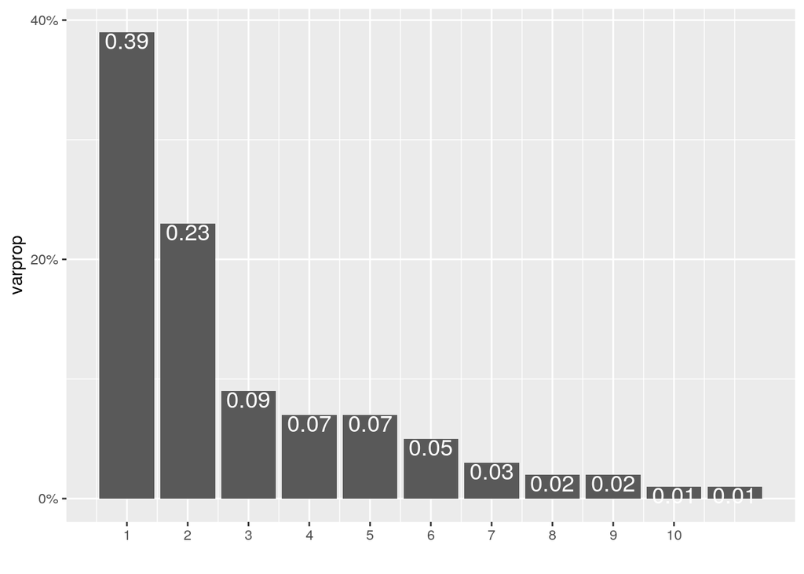

```r
eigval <- possum_pca$sdev^2
varprop = round(eigval/sum(eigval), 2)
ggplot() + geom_bar(aes(y = varprop, x = 1:11), stat = "identity") +
    xlab("") + geom_text(aes(x = 1:11, y = varprop, label = round(varprop,
    2)), vjust = 1, col = "white", size = 5) + scale_y_continuous(breaks = seq(0,
    0.6, 0.2), labels = scales::percent) + scale_x_continuous(breaks = 1:10)
```

Looking at the scree plot, you would need to keep PC1, PC2, PC3, PC4, and PC5 to reach the 80% threshold. PC1 and PC2 only account for 62% of the total variance, but the “elbow” is at PC2. In addition, only the first 2 PCs have eigenvalues greater than 1, so I decided to keep the first two PC’s. PC1 seems to represent overall possum size. Generally, site is negatively correlated with age and body measurements. Thus, the latter sites in the experiment have smaller possums. PC2 seems to delve into the body measurements more. Looking at the biplot, possums with bigger feet and longer ear conch distance (negative PC2) tend to have smaller chest girth, overall length, head length, skull width, tail length, eye distance, and age.

### Linear Classifier

```r
# Linear Regression
library(caret)
possum_lc <- possum %>% select(-Pop, -case, -site)
fit <- lm(sex == "m" ~ age + hdlngth + skullw + totlngth + taill +
    footlgth + earconch + eye + chest + belly, data = possum_lc)
summary(fit)
```

```
##
## Call:
## lm(formula = sex == "m" ~ age + hdlngth + skullw + totlngth +
##     taill + footlgth + earconch + eye + chest + belly, data = possum_lc)
##
## Residuals:
##     Min      1Q  Median      3Q     Max
## -1.0015 -0.3881  0.1090  0.3691  0.7774
##
## Coefficients:
##              Estimate Std. Error t value Pr(>|t|)
## (Intercept) -1.951929   1.731041  -1.128   0.2625
## age         -0.020123   0.027255  -0.738   0.4622
## hdlngth      0.058726   0.023357   2.514   0.0137 *
## skullw       0.018179   0.023068   0.788   0.4327
## totlngth    -0.049529   0.021536  -2.300   0.0238 *
## taill        0.025153   0.037348   0.673   0.5024
## footlgth    -0.004564   0.021824  -0.209   0.8348
## earconch     0.003706   0.022333   0.166   0.8686
## eye          0.084972   0.049719   1.709   0.0909 .
## chest       -0.036906   0.037069  -0.996   0.3221
## belly       -0.019116   0.023562  -0.811   0.4193
## ---
## Signif. codes:  0 '***' 0.001 '**' 0.01 '*' 0.05 '.' 0.1 ' ' 1
##
## Residual standard error: 0.4686 on 90 degrees of freedom
## Multiple R-squared:  0.1945, Adjusted R-squared:  0.105
## F-statistic: 2.174 on 10 and 90 DF,  p-value: 0.02645
```

```r
prob_reg <- predict(fit, type = "response")
class_diag(prob_reg, truth = possum_lc$sex, positive = "m")
```

```
##            acc   sens   spec    ppv     f1     ba    auc
## Metrics 0.6733 0.7458 0.5714 0.7097 0.7273 0.6586 0.7559
```

```r
# Confusion Matrix
x <- possum_lc$hdlngth
y <- possum_lc$sex
accuracy <- vector()
cutoff <- 1:100
for (i in cutoff) {
    y_hat <- ifelse(x > i, "m", "f")
    accuracy[i] <- mean(y == y_hat)
}
min(possum_lc$hdlngth)
```

```
## [1] 82.5
```

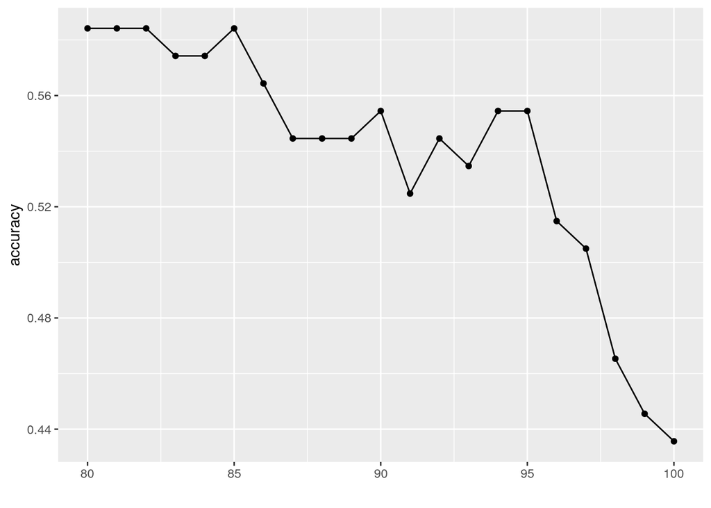

```r
qplot(y = accuracy) + geom_line() + scale_x_continuous(breaks = seq(from = 80,
    to = 100, by = 5), limits = c(80, 100))  #only show 80+ bc the min head length is 82.5
```

```r
y_hat <- ifelse(x > 85, "m", "f")
table(actual = y, predicted = y_hat) %>% addmargins
```

```
##       predicted
## actual   f   m Sum
##    f     1  41  42
##    m     1  58  59
##    Sum   2  99 101
```

```r
# cross-validation

set.seed(322)
k = 10
data <- sample_frac(possum_lc)
diags <- NULL
folds <- rep(1:k, length.out = nrow(data))
i = 1
for (i in 1:k) {

    train <- data[folds != i, ]
    test <- data[folds == i, ]
    truth <- test$sex

    fit <- lm(sex == "m" ~ age + hdlngth + skullw + totlngth +
        taill + footlgth + earconch + eye + chest + belly, data = possum_lc)
    probs <- predict(fit, newdata = test, type = "response")

    diags <- rbind(diags, class_diag(probs, truth, positive = "m"))
}
summarize_all(diags, mean)
```

```
##       acc   sens    spec     ppv      f1     ba     auc
## 1 0.67182 0.7443 0.56214 0.71786 0.72085 0.6532 0.75169
```

### Non-Parametric Classifier

```r
library(caret)
# KNN
knn_fit <- knn3(sex == "m" ~ age + hdlngth + skullw + totlngth +
    taill + footlgth + earconch + eye + chest + belly, data = possum_lc)
y_hat_knn <- predict(knn_fit, possum_lc)
class_diag(y_hat_knn[, 2], possum_lc$sex, positive = "m")
```

```
##            acc   sens   spec ppv     f1     ba    auc
## Metrics 0.7426 0.7458 0.7381 0.8 0.7719 0.7419 0.8224
```

```r
# kNN confusion matrix
y_hat_knn_mf <- ifelse(y_hat_knn > 0.5, "m", "f")
table(actual = y, predicted = y_hat_knn_mf[, 2]) %>% addmargins
```

```
##       predicted
## actual   f   m Sum
##    f    31  11  42
##    m    15  44  59
##    Sum  46  55 101
```

```r
# kNN CV
set.seed(322)
k = 10

data <- sample_frac(possum_lc)
folds <- rep(1:k, length.out = nrow(data))

diags <- NULL

i = 1
for (i in 1:k) {
    train <- data[folds != i, ]
    test <- data[folds == i, ]
    truth <- test$sex

    fit <- knn3(sex ~ age + hdlngth + skullw + totlngth + taill +
        footlgth + earconch + eye + chest + belly, data = train)


    probs <- predict(fit, newdata = test)[, 2]

    diags <- rbind(diags, class_diag(probs, truth, positive = "m"))
}


summarize_all(diags, mean)
```

```
##       acc    sens   spec     ppv      f1      ba     auc
## 1 0.54273 0.58143 0.5169 0.66083 0.59287 0.54917 0.58561
```

### Regression/Numeric Prediction

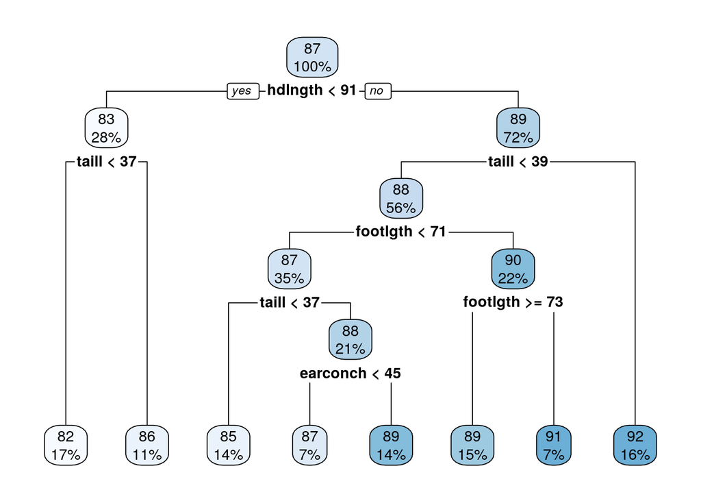

```r
# Classification Tree
library(rpart)
library(rpart.plot)
fit_tree <- rpart(totlngth ~ ., data = possum)
rpart.plot(fit_tree)
```

```r
# MSE from linear reg
yhat <- predict(fit_tree)
mean((possum$totlngth - yhat)^2)
```

```
## [1] 5.232965
```

```r
# cross-validation of regression model here
set.seed(1234)
cv <- trainControl(method = "cv", number = 10, classProbs = T,
    savePredictions = T)
fit <- train(totlngth ~ ., data = possum, trControl = cv, method = "rpart")
min(fit$results$RMSE)^2
```

```
## [1] 11.23601
```

### Python

```r
library(reticulate)
use_python("/usr/bin/python3", required = F)

rpossum <- possum %>% filter(case == 3) %>% select(sex)
rpossum
```

```
## # A tibble: 1 x 1
##   sex
##   <chr>
## 1 f
```

```python
py_python = r.rpossum
type(py_python)
```

```
## <class 'dict'>
```

In R, I found the sex of the third observation in the possum dataset, which was ‘f’. In python, I found that the class type for the sex is ‘dict’.

### Concluding Remarks

Possum body length measurements between male v. female is not as distinctive as other animals are. Initially, I predicted that total body length was more indicative of sex, but it’s surprisingly head length! The models and predictions I carried out on this possum dataset were not as strong as I predicted, but there were relationships between variables I never thought would be correlated ! Overall, this dataset was very interesting to model and predict on.